# Ecosystem Dynamics Lab 5

# Goals:

- Practice adding a new flux to a differential equation model
- Apply the simple NPZD model to a new science question
- Practice analyzing model behavior

We will apply our NPZD model (S&H Section 2.9.1) to investigate the influence of nitrogen pollution on our ecosystem. The current model has no N inputs or outputs, so we need to add the fluxes.

# Step 1: Conceptual Model

**Question 1:**

Draw a conceptual diagram (building on S&H figure 2.20 diagram) that adds two new fluxes: Dissolved inorganic nitrogen (DIN) input from agricultural run-off and DIN output from a stream that drains the lake.

**Answer 1:** F1 and F8 represent the two new fluxes in the model.

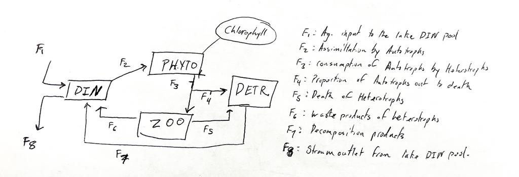

Modify your model so that the two new fluxes are now included. The modifications will not require adding any new stocks, but you will have to add two new parameters.

#Step 2: Code Model

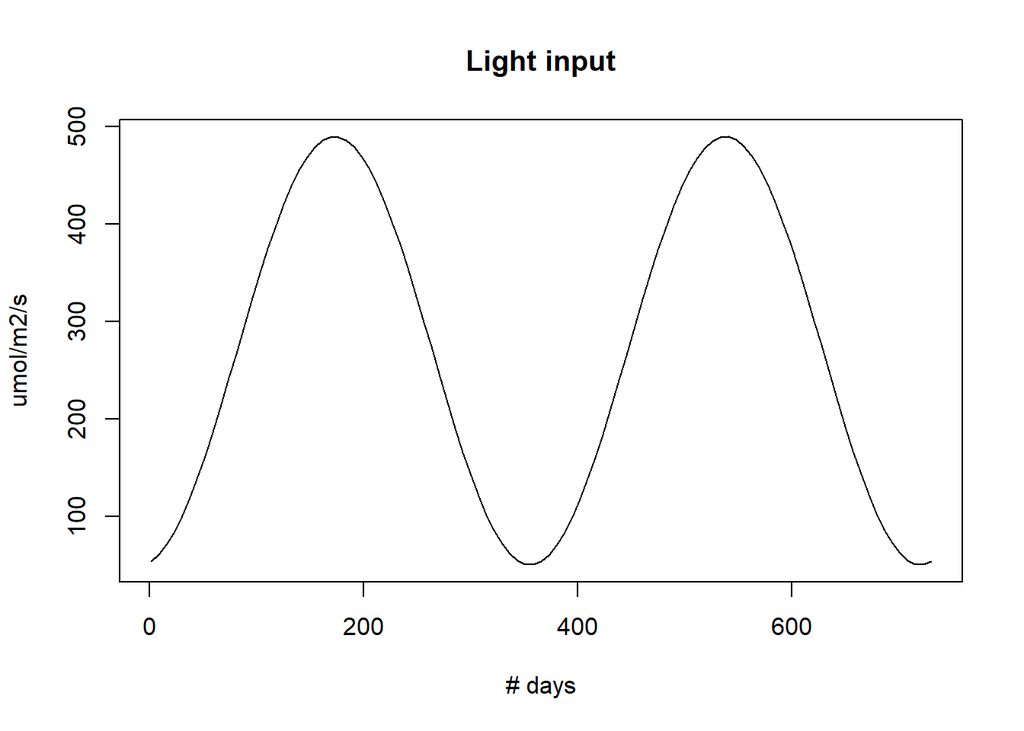

```r
light_function <- function(x){
  t <- x
  0.5 * (540 + 440 * sin(2 * pi * t / 365 - 1.4))
}

curve(light_function(x),
      from = 1, to = 730,
      ylab = "umol/m2/s",
      xlab = "# days",
      main = "Light input")
```

```r
NPZD_model <- function(t, states, parms){

  #unpack states
  PHYTO <- states[1]
  ZOO <- states[2]
  DET <- states[3]
  DIN <- states[4]

  #unpack parms
  maxUptake <- parms[1]
  kspar <- parms[2] #Sunlight Limiting
  ksdin <- parms[3] #Nitrogen limiting
  maxGrazing <- parms[4]
  ksphyto <- parms[5]
  pFeces <- parms[6] #proportion of waste to feces
  excretionRate <- parms[7]
  mortalityRate <- parms[8]
  mineralizationRate <- parms[9]
  Chl_Nratio <- parms[10]
  DINimport <- parms[11] #Inputs to DIN pool from agriculture
  DINexport <- parms[12] #Outlet from Lake into Stream

  #Calculate the environment (note that this depends on time)
  #50% of light is PAR
  PAR <- 0.5 * (540 + 440 * sin(2 * pi * t / 365 - 1.4))

  #calculate fluxes
  fDIN <- (DIN / (DIN + ksdin))
  fLight <- PAR / (PAR + kspar)
  uptake <- maxUptake * PHYTO * fDIN * fLight #min(c(fDIN, fLight))

  fPHYTO <- PHYTO / (PHYTO + ksphyto)
  grazing <- maxGrazing * ZOO * fPHYTO

  feces_production <- grazing * pFeces

  excretion <- excretionRate * ZOO

  zoo_mortality <- mortalityRate * ZOO^2

  mineralization <- mineralizationRate * DET

  #calculate extra outputs
  Chlorophyll <- PHYTO * Chl_Nratio

  #calculate derivatives
  dPHYTO_dt <- uptake - grazing
  dZOO_dt <- grazing - feces_production - zoo_mortality - excretion
  dDETRITUS_dt <- zoo_mortality + feces_production - mineralization
  dDIN_dt <- excretion + mineralization - uptake + DINimport - DINexport

 #return the list of derivatives plus any other variables that you are interested in

  return(list(c(dPHYTO_dt = dPHYTO_dt, # the rates of change
                dZOO_dt = dZOO_dt,
                dDETRITUS_dt = dDETRITUS_dt,
                dDIN_dt = dDIN_dt),
              # other output variables
              c(Chlorophyll = Chlorophyll,
                PAR = PAR)))
}
```

#Step 3: Parameterize Model

We are going to assume that the DIN output is a first-order process controlled by the DIN in the lake. The DIN output rate parameter will be the turnover rate of water in the lake (1 / residence time). Assume that the lake has a 720-day residence time.

We will assume that the DIN input is a constant equal to 0.0012 mmol N m-3 day-1.

```r
parms <- c(
  1.0,  #maxUptake (N m-3 day-1)
  120,  #kspar
  0.5,  #ksdin
  1.0,  #maxGrazing (N m-3 day-1)
  1.0,    #ksphyto
  0.3,  #pFaeces
  0.1,  #excretionRate (N m-3 day-1)
  0.4,  #mortalityRate (N m-3 day-1)
  0.1,  #mineralizationRate (N m-3 day-1)
  1.0,  #Chl_Nratio
  .0012, # DIN input (N m-3 day-1)
  .00139 #Turnover rate "export" (m-3 day-1)
  )
```

#Step 4: Initialize and Solve Model

```r
#INSERT INITIAL CONDITIONS HERE
yini <- c(
  PHYTO = 1, #mmolN m-3
  ZOO = 0.8, #mmolN m-3
  DETRITUS = 1, #mmolN m-3
  DIN = 9) #mmolN m-3

library(deSolve)
simulation_time <- (365 * 10) + (365/2)
dt <- 1
times <- seq(1, simulation_time, by = dt)

output <- ode(y = yini, times = times, func = NPZD_model, parms = parms, method = "ode45")
```

#Step 5: Verify Model

**Question 2:**

What is the mid-summer stock of phytoplankton after 10 years? Are the dynamics reasonable? Include a plot of the time series from the simulation.

**Answer 2:** The mid-summer stock of phytoplankton is 2.94 mmolN/m3 following 10 year cycles

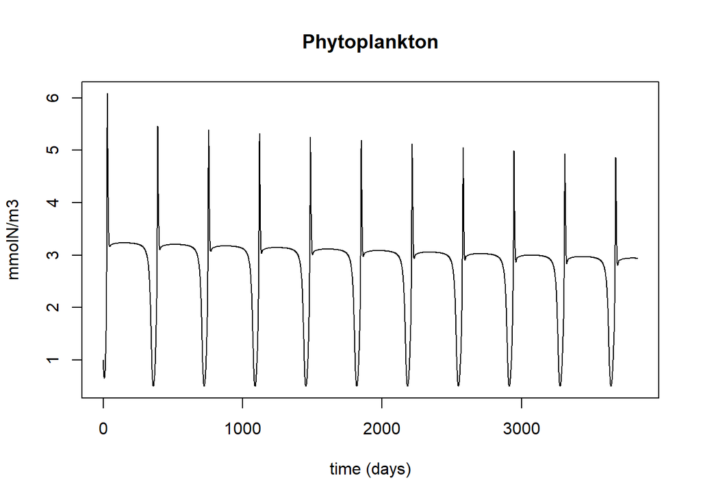

```r
#Plot the model output
#First convert output to a data frame
output <- as.data.frame(output)
#par(mfrow = c(1, 2))
#plot(times, output$PAR, xlab = "time (days)", ylab = "umol/m2/s", main = "PAR", type = "l")
plot(times, output$PHYTO, xlab="time (days)", ylab ="mmolN/m3", main = "Phytoplankton", type = "l")
```

```r
output$PHYTO[3832.5]
```

```
## [1] 2.940445
```

**Question 3:** To meet regulations, the lake needs the summer phytoplankton population to not exceed 2 mmol N m^-3 within the next 10 years.

What is the smallest reduction in agriculture run-off that will achieve this goal? Give your answer as a percentage reduction from the baseline simulation reported in question 2

**Answer 3:**

In order to meet the reduction of phytoplankton concentrations to <2 mmol N m-3 at the end of a ten year period, a reduction of agricultural inputs from 0.0012 to .0005 mmol N m-3 day -1 is needed. This is a percent reduction of 58.33%.

**Question 4:**

Provide a plot of phytoplankton over the 10-year period with and without the reduction in run-off. Ensure the figure includes a legend, properly labeled axes, and a title.

**Answer 4:**

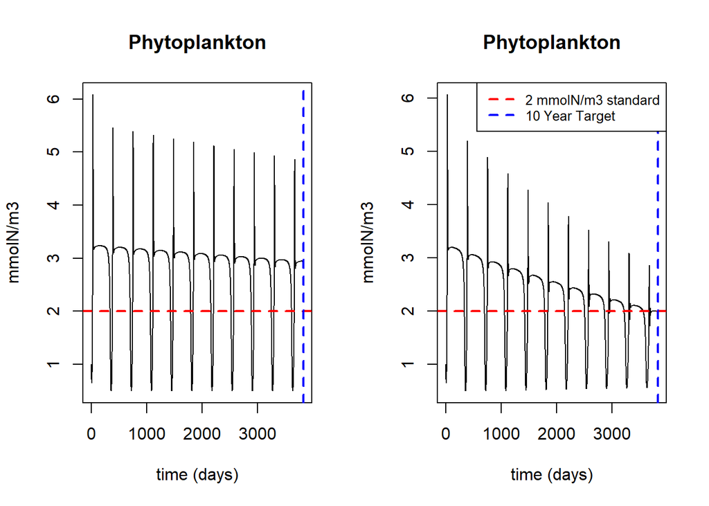

```r
parms1 <- c(
  1.0,  #maxUptake (N m-3 day-1)
  120,  #kspar
  0.5,  #ksdin
  1.0,  #maxGrazing (N m-3 day-1)
  1.0,    #ksphyto
  0.3,  #pFaeces
  0.1,  #excretionRate (N m-3 day-1)
  0.4,  #mortalityRate (N m-3 day-1)
  0.1,  #mineralizationRate (N m-3 day-1)
  1.0,  #Chl_Nratio
  .0005, # DIN input (N m-3 day-1)
  .00139 #Turnover rate "export" (m-3 day-1)
  )

output1 <- ode(y = yini, times = times, func = NPZD_model, parms = parms1, method = "ode45")

output <- as.data.frame(output)
output1 <- as.data.frame(output1)

par(mfrow = c(1, 2))
plot(times, output$PHYTO, xlab="time (days)", ylab ="mmolN/m3", main = "Phytoplankton", type = "l")
abline(h=2, col="red", lwd=2, lty=2)
abline(v=3832.5, col="blue", lwd=2, lty=2)
plot(times, output1$PHYTO, xlab="time (days)", ylab ="mmolN/m3", main = "Phytoplankton", type = "l")
abline(h=2, col="red", lwd=2, lty=2)
abline(v=3832.5, col="blue", lwd=2, lty=2)

legend("topright", legend=c("2 mmolN/m3 standard", "10 Year Target"),
       col=c("red", "blue"), lwd=2, lty=2, cex=0.8, box.lty=1)
```

#Step 7: Improve the model

**Question 5:**

You are an ecosystem scientist tasked with improving the model by better parameterizing the model that it models phytoplankton more realistically. To address this task, you are designing a field-sampling program to measure the model’s parameters. Which parameter should get the most attention in the field program and why? Provide a quantitative assessment, including a description of the approach you used to make the assessment.

Focus on the following 4 parameters: maxNuptake, maxGrazing, kspar, ksdin

**Answer 5:**

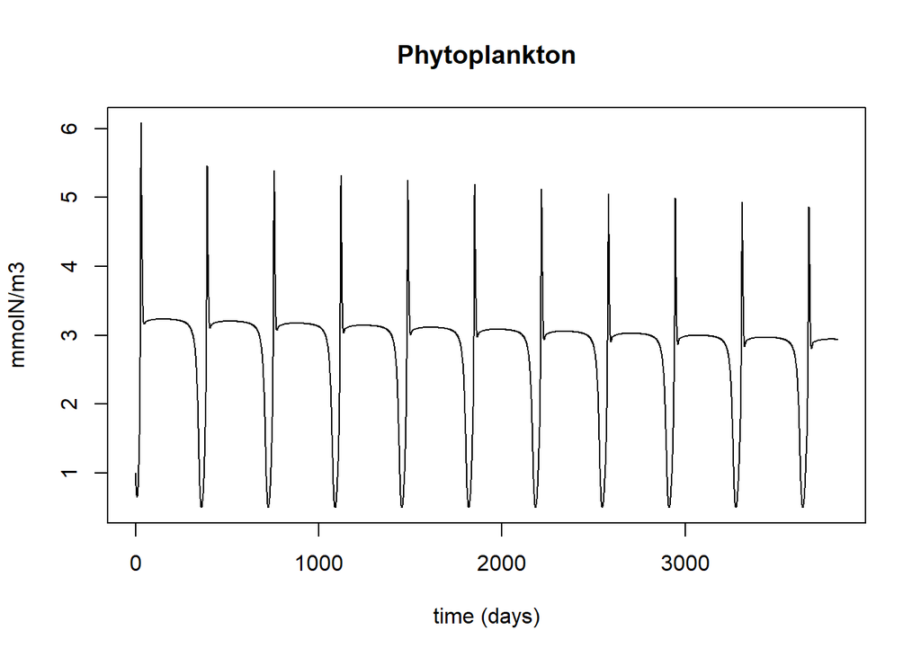

```r
# Highly nitrogen (hksDIN) limited scenario:

hksDIN <- c(
  1.0,  #maxUptake (N m-3 day-1)
  120,  #kspar
  0.75,  #ksdin
  1.0,  #maxGrazing (N m-3 day-1)
  1.0,    #ksphyto
  0.3,  #pFaeces
  0.1,  #excretionRate (N m-3 day-1)
  0.4,  #mortalityRate (N m-3 day-1)
  0.1,  #mineralizationRate (N m-3 day-1)
  1.0,  #Chl_Nratio
  .0012, # DIN input (N m-3 day-1)
  .00139 #Turnover rate "export" (m-3 day-1)
  )

# Highly sunlight (hkspar) limited scenario:

hkspar <- c(
  1.0,  #maxUptake (N m-3 day-1)
  180,  #kspar
  0.5,  #ksdin
  1.0,  #maxGrazing (N m-3 day-1)
  1.0,    #ksphyto
  0.3,  #pFaeces
  0.1,  #excretionRate (N m-3 day-1)
  0.4,  #mortalityRate (N m-3 day-1)
  0.1,  #mineralizationRate (N m-3 day-1)
  1.0,  #Chl_Nratio
  .0012, # DIN input (N m-3 day-1)
  .00139 #Turnover rate "export" (m-3 day-1)
  )

# lower max uptake (lmu) scenario:

lMU <- c(
  .5,  #maxUptake (N m-3 day-1)
  120,  #kspar
  0.5,  #ksdin
  1.0,  #maxGrazing (N m-3 day-1)
  1.0,    #ksphyto
  0.3,  #pFaeces
  0.1,  #excretionRate (N m-3 day-1)
  0.4,  #mortalityRate (N m-3 day-1)
  0.1,  #mineralizationRate (N m-3 day-1)
  1.0,  #Chl_Nratio
  .0012, # DIN input (N m-3 day-1)
  .00139 #Turnover rate "export" (m-3 day-1)
  )

# lower max grazing (lmg) scenario:

hkspar <- c(
  1.0,  #maxUptake (N m-3 day-1)
  120,  #kspar
  0.5,  #ksdin
  .5,  #maxGrazing (N m-3 day-1)
  1.0,    #ksphyto
  0.3,  #pFaeces
  0.1,  #excretionRate (N m-3 day-1)
  0.4,  #mortalityRate (N m-3 day-1)
  0.1,  #mineralizationRate (N m-3 day-1)
  1.0,  #Chl_Nratio
  .0012, # DIN input (N m-3 day-1)
  .00139 #Turnover rate "export" (m-3 day-1)
  )

output2 <- ode(y = yini, times = times, func = NPZD_model, parms = hksDIN, method = "ode45")
output3 <- ode(y = yini, times = times, func = NPZD_model, parms = hkspar, method = "ode45")
output4 <- ode(y = yini, times = times, func = NPZD_model, parms = lMU, method = "ode45")
output5 <- ode(y = yini, times = times, func = NPZD_model, parms = hkspar, method = "ode45")

output2 <- as.data.frame(output2)
output3 <- as.data.frame(output3)
output4 <- as.data.frame(output4)
output5 <- as.data.frame(output5)

plot(times, output$PHYTO, xlab="time (days)", ylab ="mmolN/m3", main = "Phytoplankton", type = "l")
```

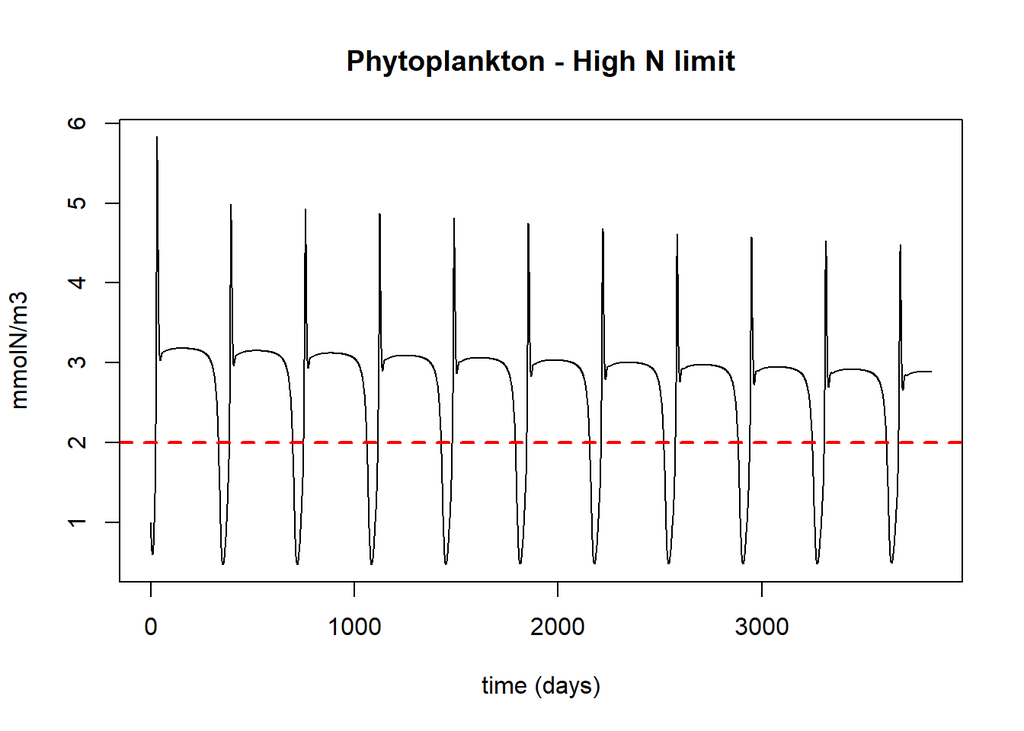

```r
plot(times, output2$PHYTO, xlab="time (days)", ylab ="mmolN/m3", main = "Phytoplankton - High N limit", type = "l")
abline(h=2, col="red", lwd=2, lty=2)
```

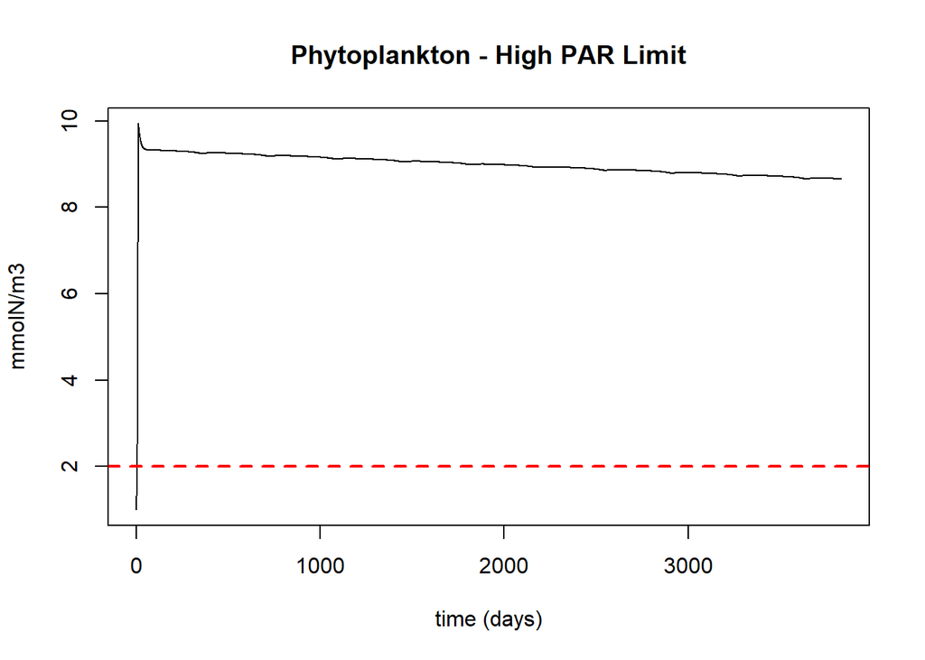

```r
plot(times, output3$PHYTO, xlab="time (days)", ylab ="mmolN/m3", main = "Phytoplankton - High PAR Limit", type = "l")
abline(h=2, col="red", lwd=2, lty=2)
```

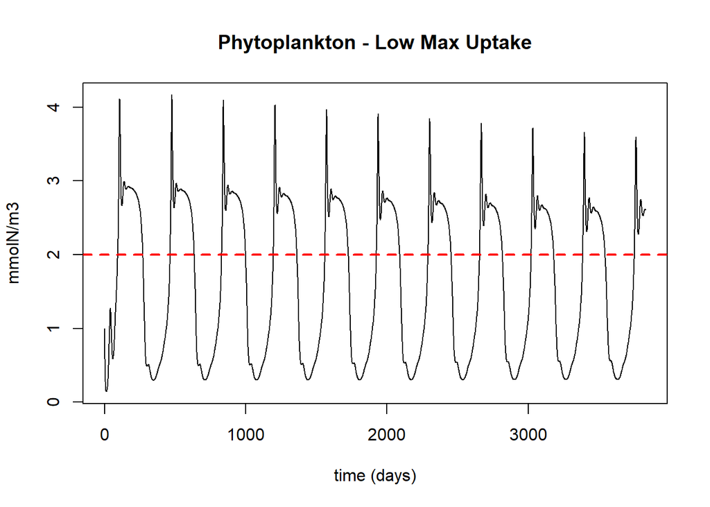

```r
plot(times, output4$PHYTO, xlab="time (days)", ylab ="mmolN/m3", main = "Phytoplankton - Low Max Uptake", type = "l")
abline(h=2, col="red", lwd=2, lty=2)
```

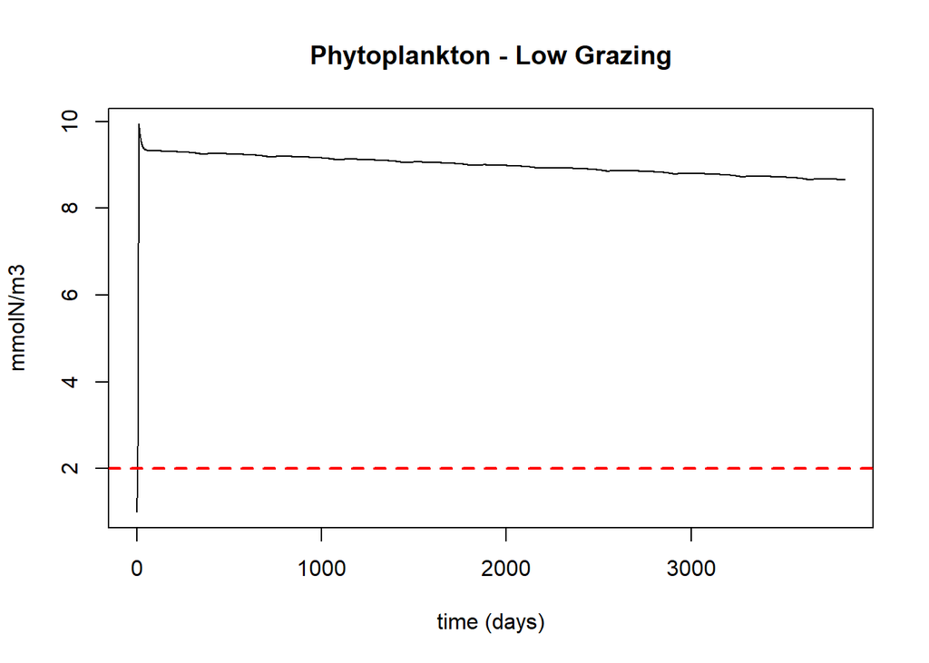

```r
plot(times, output5$PHYTO, xlab="time (days)", ylab ="mmolN/m3", main = "Phytoplankton - Low Grazing", type = "l")
abline(h=2, col="red", lwd=2, lty=2)
```

```r
output2$PHYTO[3832.5]/output$PHYTO[3832.5]
```

```
## [1] 0.9825952
```

```r
output3$PHYTO[3832.5]/output$PHYTO[3832.5]
```

```
## [1] 2.944694
```

```r
output4$PHYTO[3832.5]/output$PHYTO[3832.5]
```

```
## [1] 0.887041
```

```r
output5$PHYTO[3832.5]/output$PHYTO[3832.5]
```

```
## [1] 2.944694
```